# Team Performance Analysis by Geographical Region (Using NBA Games from 2000 - 2024)

## Home Wins Percentage

```python
# Overall Home win percentage (by season)
nba_home = nba_df.groupby(['Season', 'Team', 'Home']).agg({'W/L': 'sum'})
nba_home = pd.merge(nba_home,
                    nba_df.groupby(['Season', 'Team', 'Home']).agg({'G': 'count'}),
                    on = ['Season', 'Team', 'Home'],
                    how = 'inner')
nba_home['Win%'] = nba_home['W/L']/nba_home['G']
nba_home.reset_index(inplace=True)
nba_home.to_csv('nba_home_seasons.csv', index = False)
nba_home.head(5)
```

|  | Season | Team | Home | W/L | G | Win% |
| --- | --- | --- | --- | --- | --- | --- |
| 0 | 2000 | ATL | 0 | 7 | 41 | 0.170732 |
| 1 | 2000 | ATL | 1 | 21 | 41 | 0.512195 |
| 2 | 2000 | BOS | 0 | 9 | 41 | 0.219512 |
| 3 | 2000 | BOS | 1 | 26 | 41 | 0.634146 |
| 4 | 2000 | CHI | 0 | 5 | 41 | 0.121951 |

```python
# Overall Home win percentage (overall)
nba_home_overall = nba_home.groupby(['Team', 'Home']).agg({'W/L': 'sum', 'G': 'sum'})
nba_home_overall['Win%'] = nba_home_overall['W/L']/nba_home_overall['G']
nba_home_overall.reset_index(inplace=True)

# Left join with team division information
nba_home_overall = pd.merge(nba_home_overall,
                            df_nba_team_division,
                            how='left',
                            left_on='Team',
                            right_on='Team')

# Separate the DataFrame into home and away data
home_df = nba_home_overall[nba_home_overall['Home'] == 1]
away_df = nba_home_overall[nba_home_overall['Home'] == 0]

# Create traces for home and away win percentages for each team
home_trace = go.Bar(x=home_df['Team'], y=home_df['Win%'], name='Home', marker_color='#93CBDD')
away_trace = go.Bar(x=away_df['Team'], y=away_df['Win%'], name='Away', marker_color='#FF8BA1')

# Create the figure
fig = go.Figure(data=[home_trace, away_trace])

# Add hlines at home and away win percentages
home_win_pt = np.round(home_df['W/L'].sum() / home_df['G'].sum(), 2)
away_win_pt = np.round(away_df['W/L'].sum() / away_df['G'].sum(), 2)

fig.add_hline(y = home_win_pt, line_dash="dash", line_color="#93CBDD") # Home avg
fig.add_hline(y = away_win_pt, line_dash="dash", line_color="#FF8BA1") # Away avg

# Update the layout
fig.update_layout(title='Win Percentage by Team at Home and Away',
                  xaxis_title='Team',
                  yaxis_title='Win Percentage')
fig.update_layout(width = 1400, height = 400)
fig.show()
```

```python
# Home win percentage over the years
nba_overall = nba_df.groupby(['Season', 'Home']).agg({'W/L': 'sum'})
nba_overall = pd.merge(nba_overall,
                    nba_df.groupby(['Season','Home']).agg({'G': 'count'}),
                    on = ['Season','Home'],
                    how = 'inner')
nba_overall['Win%'] = nba_overall['W/L']/nba_overall['G']
nba_overall.reset_index(inplace=True)

fig = go.Figure()
fig.add_trace(go.Scatter(x = nba_overall[nba_overall['Home'] == 1]['Season'],
                         y = nba_overall[nba_overall['Home'] == 1]['Win%'],
                         mode='lines',
                         name='Home win%',
                         line=dict(width=2.5, color='#1D428A')))
# fig = px.line(df, x='Date', y=df.columns[1:-6])
fig.add_vrect(x0=2019.5, x1=2022.5, line_width=0, fillcolor="red", opacity=0.2,
              annotation_text="Drop possibly due to COVID-19 <br>Lockdown NBA", annotation_position="top left")
fig.add_annotation(x=2010, y=0.545, text="<i>*Axis zoomed in to highlight trends</i>", showarrow=False, arrowhead=0)
fig.update_layout(title='Win percentage by home team over the years*',
                  xaxis_title='Season',
                  yaxis_title='Win Percentage')

# Get Division level stats and add it to trace
nba_division_stats = pd.merge(nba_home, df_nba_team_division, on = 'Team', how = 'inner')
nba_division_stats = nba_division_stats.groupby(['Season', 'Home', 'Division']).agg({'W/L': 'sum', 'G': 'sum'})
nba_division_stats.reset_index(inplace=True)
nba_division_stats['Win%'] = nba_division_stats['W/L']/nba_division_stats['G']

for division in nba_division_stats['Division'].unique():
    division_data = nba_division_stats[nba_division_stats['Division'] == division]
    division_data = division_data[division_data['Home'] == 1]
    fig.add_trace(go.Scatter(x = division_data['Season'], y = division_data['Win%'], mode = 'lines', name = division, line=dict(width=1, color = '#8E918F'), opacity = 0.4, showlegend=False))

fig.show()
```

```python
# Other metrics dataset (Home vs away)
# 3P%, FT%, FG%
nba_other_metrics = nba_df.groupby(['Team', 'Home']).agg({'Tm_3P': 'sum', 'Tm_3PA': 'sum', 'Tm_FT': 'sum', 'Tm_FTA': 'sum', 'Tm_FG': 'sum', 'Tm_FGA': 'sum'})
nba_other_metrics.reset_index(inplace = True)
nba_other_metrics.head()

nba_other_metrics['Tm_3P%'] = np.round(nba_other_metrics['Tm_3P']/nba_other_metrics['Tm_3PA'], 2)
nba_other_metrics['Tm_FT%'] = np.round(nba_other_metrics['Tm_FT']/nba_other_metrics['Tm_FTA'], 2)
nba_other_metrics['Tm_FG%'] = np.round(nba_other_metrics['Tm_FG']/nba_other_metrics['Tm_FGA'], 2)

nba_other_metrics.head()
```

|  | Team | Home | Tm_3P | Tm_3PA | Tm_FT | Tm_FTA | Tm_FG | Tm_FGA | Tm_3P% | Tm_FT% | Tm_FG% |
| --- | --- | --- | --- | --- | --- | --- | --- | --- | --- | --- | --- |
| 0 | ATL | 0 | 7294 | 20696 | 16697 | 21901 | 35470 | 79565 | 0.35 | 0.76 | 0.45 |
| 1 | ATL | 1 | 7567 | 21077 | 17656 | 22944 | 37024 | 80178 | 0.36 | 0.77 | 0.46 |
| 2 | BOS | 0 | 8195 | 23013 | 17642 | 22881 | 35784 | 79321 | 0.36 | 0.77 | 0.45 |
| 3 | BOS | 1 | 8254 | 22850 | 17442 | 22637 | 36680 | 79745 | 0.36 | 0.77 | 0.46 |
| 4 | BRK | 0 | 4672 | 13094 | 7814 | 10134 | 17222 | 37710 | 0.36 | 0.77 | 0.46 |

## At the free throw line

Do home teams have an advantage at the free throw line?

```python
# How teams fared at the free throw line (home and away)
# Create traces for home and away FT% percentages for each team
home_ft = go.Bar(x=nba_other_metrics[nba_other_metrics['Home'] == 1]['Team'],
                    y=nba_other_metrics[nba_other_metrics['Home'] == 1]['Tm_FT%'],
                    name='Home',
                    marker_color='#93CBDD')
away_ft = go.Bar(x=nba_other_metrics[nba_other_metrics['Home'] == 0]['Team'],
                    y=nba_other_metrics[nba_other_metrics['Home'] == 0]['Tm_FT%'],
                    name='Home',
                    marker_color='#FF8BA1')

fig = go.Figure(data=[home_ft, away_ft])
# Add hlines at home and away win percentages
home_ft = np.round(nba_other_metrics[nba_other_metrics['Home'] == 1]['Tm_FT'].sum() / nba_other_metrics[nba_other_metrics['Home'] == 1]['Tm_FTA'].sum(), 2)
away_ft = np.round(nba_other_metrics[nba_other_metrics['Home'] == 0]['Tm_FT'].sum() / nba_other_metrics[nba_other_metrics['Home'] == 0]['Tm_FTA'].sum(), 2)

fig.add_hline(y = home_ft, line_dash="dash", line_color="#93CBDD") # Home avg
fig.add_hline(y = away_ft, line_dash="dash", line_color="#FF8BA1") # Away avg

# Update the layout
fig.update_layout(title='FT% by Team at Home and Away',
                  xaxis_title='Team',
                  yaxis_title='FT%')
fig.update_layout(width = 1400, height = 400)
# fig.write_image("plots/nbaHomeWins.png", engine='kaleido')
fig.show()
```

## Win and Loss Margins

When teams win at home, do they win big?  
Similarly, when teams lose at home, is their loss margin lower than when they lose at away fixtures?

```python
# Win and Lose Margins (Home and Away)
nba_margin = nba_df.groupby(['Home', 'W/L']).agg({'Tm_Pts': np.average, 'Opp_Pts': np.average}).reset_index()
nba_margin['Tm_Pts'] = np.round(nba_margin['Tm_Pts'], 2)
nba_margin['Opp_Pts'] = np.round(nba_margin['Opp_Pts'], 2)
nba_margin['Delta_Pts'] = nba_margin['Tm_Pts'] - nba_margin['Opp_Pts']

# Heatmap plot
heatmap = nba_margin.pivot(index = 'Home', columns = 'W/L', values = 'Delta_Pts')
fig = go.Figure(data=go.Heatmap(z=np.round(heatmap.values, 2),
                                x=['Loss', 'Win'],
                                y=['Away', 'Home'],
                                colorscale='YlGn',
                                hoverongaps = False,
                                text=[['Away Loss', 'Away Win'],
                                ['Home Loss', 'Home Win']],
                                texttemplate="%{text} <br> Differential <br><br> <i><b>%{z}"))
# Update layout
fig.update_layout(title='Margin of Wictory/Loss (Home and Away)',
                  xaxis_title='W/L',
                  yaxis_title='Venue')
fig.update_layout(width = 500, height = 500)
fig.update_traces(showscale = False)

# Show the plot
fig.show()
```

Over the years the average team score has consistently increased from 103 (in 2000) to 120.5 (in 2023) at the home venue. The away wins follow a similar pattern (101.8 to 120)

```python
# Margin of wictory/loss trends (home and away)
nba_margin = nba_df.groupby(['Home', 'Season', 'W/L']).agg({'Tm_Pts': np.average, 'Opp_Pts': np.average}).reset_index()
nba_margin.Tm_Pts, nba_margin.Opp_Pts = nba_margin.Tm_Pts.round(1), nba_margin.Opp_Pts.round(1) # Round to 1 decimal place

# Get data for each season, home and status
fig = go.Figure()
for home in nba_margin.Home.unique():
    for status in nba_margin['W/L'].unique():
        home_label = 'Home' if home > 0 else 'Away'
        status_label = 'Win' if status == 1 else 'Loss'
        label = f"{home_label} {status_label}"

        trace_df = nba_margin[((nba_margin.Home == home) & (nba_margin['W/L'] == status))]
        fig.add_trace(go.Scatter(x = trace_df['Season'], y = trace_df['Tm_Pts'],
                                 mode = 'none',
                                 fill = 'tonexty',
                                 text = label,
                                 name = label))
fig.update_layout(title = 'Margin of Wins/Losses (Home and Away)',
                  xaxis_title = 'Season',
                  yaxis_title = 'Points scored (mean)')
fig.update_yaxes(range = [85, 120])

fig.show()
```

## Date differences between games

Hypothesis. Fewer days between games will result in poor outcomes.

```python
# Get Date Difference Between Games
df_window = nba_df.groupby(['Season', 'Team']).agg({'W/L': 'count'})
df_window.reset_index(inplace=True)

# Datediff
try:
    nba_df.insert(loc = 4, column = 'Datediff', value = nba_df.groupby(['Season', 'Team'])['Date'].diff().dt.total_seconds().div(3600*24))
except:
    pass

# print(type(nba_df['Datediff'][0])
# Value counts Date Difference Between Games
schedule_counts = nba_df[(nba_df['Datediff'] < 10) & (nba_df['Home'] == 1)].value_counts('Datediff').sort_values(ascending = False)
schedule_counts.sort_index(inplace=True)
fig = px.bar(schedule_counts, x=schedule_counts.index, y=schedule_counts.values, text_auto=True, labels={'x':'Datediff', 'y':'Counts'})
fig.update_layout(title_text='Date difference between games',
                  xaxis_title ='Date difference between games',
                  yaxis_title='# of matches')
fig.update_traces(textposition='outside')
fig.add_vrect(x0=1.5, x1=2.5, fillcolor="green", opacity=0.3, line_width=0)
fig.add_annotation(x=3.5, y=14e3, text="Most game schedules have a <br> two day difference between games", showarrow=False, arrowhead=0)
fig.show()
```

```python
# Wins by Date Differences
nba_datediff = pd.DataFrame()

for datediff in nba_df['Datediff'].unique():
    try:
        # Away
        temp = nba_df[(nba_df['Datediff'] == datediff) & (nba_df['Home'] == 0)]
        win_pt = np.round(temp['W/L'].sum() / temp.shape[0], 2)
        nba_datediff = pd.concat([nba_datediff, pd.DataFrame({'Datediff': [np.round(datediff, 0)],
                                                              'Winpt': [win_pt],
                                                              'Games': [temp.shape[0]],
                                                              'home': 1})])
        # Home
        temp = nba_df[(nba_df['Datediff'] == datediff) & (nba_df['Home'] == 1)]
        win_pt = np.round(temp['W/L'].sum() / temp.shape[0], 2)
        nba_datediff = pd.concat([nba_datediff, pd.DataFrame({'Datediff': [np.round(datediff, 0)],
                                                              'Winpt': [win_pt],
                                                              'Games': [temp.shape[0]],
                                                              'home': 0})])
    except:
        pass

nba_datediff.sort_values('Datediff', ascending = True, inplace = True)
nba_datediff = nba_datediff[nba_datediff.Datediff < 6]
nba_datediff.head(5)
```

|  | Datediff | Winpt | Games | home |
| --- | --- | --- | --- | --- |
| 0 | 1.0 | 0.38 | 7911 | 1 |
| 0 | 1.0 | 0.57 | 4012 | 0 |
| 0 | 2.0 | 0.43 | 14006 | 1 |
| 0 | 2.0 | 0.60 | 16217 | 0 |
| 0 | 3.0 | 0.42 | 3434 | 1 |

## Win% as a Factor of Date Differences

```python
# Home and away games with Datediff with their win percentages
# Home-Away or Away-Away (Home = 1)
# Home-Home or Away-Home (Home = 0)

home_games = go.Bar(
    x=nba_datediff[nba_datediff['home'] == 1]['Datediff'],
    y=nba_datediff[nba_datediff['home'] == 1]['Winpt'],
    name='Home Games',
    marker_color='#93CBDD')

away_games = go.Bar(
    x=nba_datediff[nba_datediff['home'] == 0]['Datediff'],
    y=nba_datediff[nba_datediff['home'] == 0]['Winpt'],
    name='Away Games',
    marker_color='#FF8BA1')

fig = go.Figure(data=[home_games, away_games])

# Update the layout
fig.update_layout(title='Win% by Team at Home and Away',
                  xaxis_title='Date difference between games',
                  yaxis_title='Win%')
fig.update_layout(width = 800, height = 400)
fig.show()
```

## Analyzing Margin of Victories

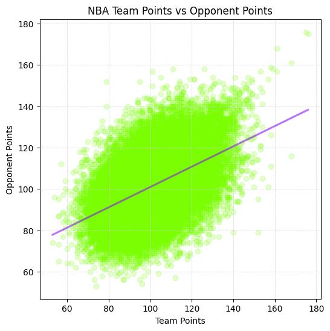

```python
# Team points vs Opponent Points
plt.figure(figsize = (6, 6), dpi = 100)
sns.regplot(data = nba_df, x = 'Tm_Pts', y = 'Opp_Pts',
            color = '#7AFE01', scatter_kws = {'alpha': 0.2}, line_kws={'color': '#8501FE', 'alpha': 0.5}, ci = 70)
plt.title('NBA Team Points vs Opponent Points')
plt.xlabel('Team Points')
plt.ylabel('Opponent Points')
plt.grid(True, which='both', linestyle='--', color='#d3d3d3', linewidth=0.5)
plt.show()
```

## Team Points and the Effect of Three Pointers

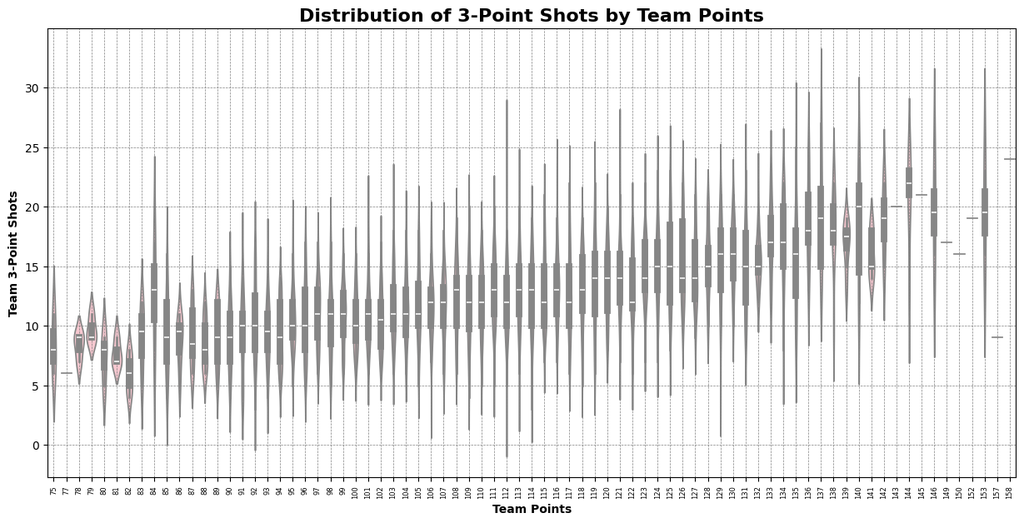

```python
plt.figure(figsize = (15, 7))
nba_df_2022 = nba_df[nba_df['Season'] == 2022]
sns.violinplot(data = nba_df_2022,
               x = 'Tm_Pts',
               y = 'Tm_3P',
               color = 'pink')
plt.title('Distribution of 3-Point Shots by Team Points', fontsize=16, weight='bold')
plt.xlabel('Team Points', weight='bold')
plt.ylabel('Team 3-Point Shots', weight='bold')
plt.grid(True, which='both', linestyle='--', color='grey', linewidth=0.5)
plt.xticks(fontsize=6, rotation = 90)
plt.show()
```

## Plot where the arenas are located

```python
# Create wins column
win_ratio = nba_df.groupby(['Team']).agg({'W/L': 'sum', 'G': 'count'}).reset_index()
win_ratio['ratio'] = round(win_ratio['W/L'] / win_ratio['G'], 1)
win_ratio

# Define team coordinates
team_coordinates = {
    'ATL': (33.7577, -84.4000),
    'BOS': (42.3601, -71.0589),
    'BRK': (40.6782, -73.9442),
    'CHO': (35.2271, -80.8431),
    'CHI': (41.8781, -87.6298),
    'CLE': (41.4993, -81.6944),
    'DAL': (32.7767, -96.7970),
    'DEN': (39.7392, -104.9903),
    'DET': (42.3314, -83.0458),
    'GSW': (37.7749, -122.4194),
    'HOU': (29.7604, -95.3698),
    'IND': (39.7684, -86.1581),
    'LAC': (34.0522, -118.2437),
    'LAL': (34.0522, -118.2437),
    'MEM': (35.1495, -90.0490),
    'MIA': (25.7617, -80.1918),
    'MIL': (43.0389, -87.9065),
    'MIN': (44.9778, -93.2650),
    'NOP': (29.9511, -90.0715),
    'NYK': (40.7128, -74.0060),
    'OKC': (35.4676, -97.5164),
    'ORL': (28.5383, -81.3792),
    'PHI': (39.9526, -75.1652),
    'PHX': (33.4484, -112.0740),
    'POR': (45.5152, -122.6784),
    'SAC': (38.5816, -121.4944),
    'SAS': (29.4241, -98.4936),
    'TOR': (43.651070, -79.347015),
    'UTA': (40.7608, -111.8910),
    'WAS': (38.9072, -77.0369)
}

# Convert to DataFrame
team_locations = pd.DataFrame.from_dict(team_coordinates, orient='index', columns=['lat', 'lon'])
team_locations['team'] = team_locations.index

# Create interactive map of team locations with OpenStreetMap style
fig_map = px.scatter_mapbox(team_locations,
                            lat='lat',
                            lon='lon',
                            hover_name='team',
                            title='NBA Team Locations',
                            mapbox_style="open-street-map",
                            size_max=1,
                            zoom=3.5,
                            center={"lat": 37.0902, "lon": -95.7129})
fig_map.update_layout(margin={"r":0,"t":0,"l":0,"b":0})
fig_map.show()
team_locations = pd.merge(win_ratio, team_locations, left_on='Team', right_on='team')

# Create heatmap of team performance with OpenStreetMap style
fig_heatmap = px.density_mapbox(team_locations, lat='lat', lon='lon', z='ratio', radius=30,
                                center=dict(lat=37.0902, lon=-95.7129), zoom=3,
                                mapbox_style="open-street-map", title='Team Performance Heatmap',
                                color_continuous_scale=px.colors.sequential.Plasma)
fig_heatmap.update_layout(margin={"r":0,"t":0,"l":0,"b":0})
fig_heatmap.show()
```

```python
!pip install geopy
```

## Celtics - Overall Performance

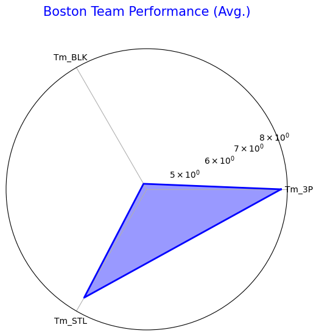

```python
boston_df = nba_df[nba_df['Team'] == 'BOS']
categories = ['Tm_3P', 'Tm_BLK', 'Tm_STL']
values = boston_df[categories].mean().tolist()
values += values[:1]  # to close the circle

# Number of variables we're plotting
num_vars = len(categories)

# Compute angle for each category
import math
angles = [n / float(num_vars) * 2 * math.pi for n in range(num_vars)]
angles += angles[:1]

# Initialise the spider plot
fig, ax = plt.subplots(figsize=(6, 6), subplot_kw=dict(polar=True))

# Draw one axe per variable and add labels
plt.xticks(angles[:-1], categories)

# Draw y-labels
ax.set_rscale('log')
ax.plot(angles, values, linewidth=1, linestyle='solid', color='blue')
ax.fill(angles, values, color='blue', alpha=0.4)

# Add a title
plt.title('Boston Team Performance (Avg.)', size=15, color='blue', y=1.1)

plt.show()
```

```python
team_locations = {
    'ATL': (33.7490, -84.3880),  # Atlanta Hawks
    'BOS': (42.3601, -71.0589),  # Boston Celtics
    'BKN': (40.6826, -73.9754),  # Brooklyn Nets
    'CHA': (35.2271, -80.8431),  # Charlotte Hornets
    'CHI': (41.8781, -87.6298),  # Chicago Bulls
    'CLE': (41.4993, -81.6944),  # Cleveland Cavaliers
    'DAL': (32.7767, -96.7970),  # Dallas Mavericks
    'DEN': (39.7392, -104.9903), # Denver Nuggets
    'DET': (42.3314, -83.0458),  # Detroit Pistons
    'GSW': (37.7680, -122.3877), # Golden State Warriors
    'HOU': (29.7604, -95.3698),  # Houston Rockets
    'IND': (39.7684, -86.1581),  # Indiana Pacers
    'LAC': (34.0430, -118.2673), # Los Angeles Clippers
    'LAL': (34.0430, -118.2673), # Los Angeles Lakers
    'MEM': (35.1495, -90.0490),  # Memphis Grizzlies
    'MIA': (25.7617, -80.1918),  # Miami Heat
    'MIL': (43.0389, -87.9065),  # Milwaukee Bucks
    'MIN': (44.9778, -93.2650),  # Minnesota Timberwolves
    'NOP': (29.9511, -90.0715),  # New Orleans Pelicans
    'NYK': (40.7128, -74.0060),  # New York Knicks
    'OKC': (35.4676, -97.5164),  # Oklahoma City Thunder
    'ORL': (28.5383, -81.3792),  # Orlando Magic
    'PHI': (39.9526, -75.1652),  # Philadelphia 76ers
    'PHX': (33.4484, -112.0740), # Phoenix Suns
    'POR': (45.5152, -122.6784), # Portland Trail Blazers
    'SAC': (38.5816, -121.4944), # Sacramento Kings
    'SAS': (29.4241, -98.4936),  # San Antonio Spurs
    'TOR': (43.651070, -79.347015), # Toronto Raptors
    'UTA': (40.7608, -111.8910), # Utah Jazz
    'WAS': (38.9072, -77.0369),  # Washington Wizards
}

# Haversine function to calculate distance
def haversine(coord1, coord2):
    import math

    R = 6371  # Radius of the earth in km
    lat1, lon1 = coord1
    lat2, lon2 = coord2
    dlat = math.radians(lat2 - lat1)
    dlon = math.radians(lon2 - lon1)
    a = math.sin(dlat / 2) * math.sin(dlat / 2) + math.cos(math.radians(lat1)) * math.cos(math.radians(lat2)) * math.sin(dlon / 2) * math.sin(dlon / 2)
    c = 2 * math.atan2(math.sqrt(a), math.sqrt(1 - a))
    distance = R * c * 0.621371  # Convert to miles
    return distance

# Expanded sample data structure for `nba_games_cleaned`
data = {
    'Season': [2023, 2023, 2023, 2023, 2023, 2023, 2023, 2023, 2023, 2023, 2023, 2023, 2023, 2023, 2023, 2023,
               2023, 2023, 2023, 2023, 2023, 2023, 2023, 2023, 2023, 2023, 2023, 2023, 2023, 2023],
    'Team': ['ATL', 'BOS', 'CHA', 'CHI', 'CLE', 'DAL', 'DEN', 'DET', 'GSW', 'HOU', 'IND', 'LAC', 'LAL', 'MEM',
             'MIA', 'MIL', 'MIN', 'NOP', 'NYK', 'OKC', 'ORL', 'PHI', 'PHX', 'POR', 'SAC', 'SAS', 'TOR', 'UTA',
             'WAS', 'BKN'],
    'G': [1] * 30,
    'Date': ['2023-10-19'] * 30,
    'Home': [0, 1, 0, 1, 0, 1, 0, 1, 0, 1, 0, 1, 0, 1, 0, 1, 0, 1, 0, 1, 0, 1, 0, 1, 0, 1, 0, 1, 0, 1],
    'Opp': ['BOS', 'ATL', 'CHI', 'CHA', 'DAL', 'CLE', 'DET', 'DEN', 'HOU', 'GSW', 'LAC', 'IND', 'MEM', 'LAL',
            'MIL', 'MIA', 'NYK', 'OKC', 'ORL', 'PHI', 'PHX', 'POR', 'SAC', 'SAS', 'TOR', 'UTA', 'WAS', 'BKN',
            'ATL', 'BOS'],
    'W/L': ['L', 'W', 'L', 'W', 'L', 'W', 'L', 'W', 'L', 'W', 'L', 'W', 'L', 'W', 'L', 'W', 'L', 'W', 'L', 'W',
            'L', 'W', 'L', 'W', 'L', 'W', 'L', 'W', 'L', 'W'],
    'Tm_Pts': [100, 120, 110, 115, 102, 125, 95, 121, 108, 119, 104, 123, 106, 117, 112, 118, 107, 116, 105, 113,
               109, 122, 114, 127, 111, 120, 118, 124, 101, 119],
    'Opp_Pts': [110, 100, 115, 110, 107, 115, 100, 110, 112, 105, 111, 101, 115, 105, 118, 108, 112, 107, 114,
                106, 113, 104, 108, 109, 115, 103, 105, 115, 107, 105],
}

nba_games_cleaned = pd.DataFrame(data)

# Calculate distance traveled for each game
def calculate_distance(row):
    home_coords = team_locations[row['Team']]
    opp_coords = team_locations[row['Opp']]
    return haversine(home_coords, opp_coords)

nba_games_cleaned['Distance'] = nba_games_cleaned.apply(calculate_distance, axis=1)

# Aggregate total distance traveled by each team
team_distances = nba_games_cleaned.groupby('Team')['Distance'].sum().reset_index()

# Calculate win percentage for each team
team_wins = nba_games_cleaned[nba_games_cleaned['W/L'] == 'W'].groupby('Team').size().reset_index(name='Wins')
team_games = nba_games_cleaned.groupby('Team').size().reset_index(name='Games')
team_performance = pd.merge(team_wins, team_games, on='Team')
team_performance['Win_Percentage'] = team_performance['Wins'] / team_performance['Games']

# Merge distance and performance data
team_stats = pd.merge(team_distances, team_performance, on='Team')
team_stats = pd.merge(team_stats, win_ratio, left_on='Team', right_on='Team')
# Create an interactive plot with plotly
fig = px.scatter(team_stats, x='Distance', y='ratio', text='Team',
                 labels={'Distance': 'Total Distance Traveled (miles)', 'Win_Percentage': 'Win Percentage'},
                 title='NBA Teams: Distance Traveled vs Performance')

fig.update_traces(textposition='top center')

fig.show()
```